# STOR 455 Homework 8

*DATA PREP*

```r
library(readr)
library(mosaic)
library(Stat2Data)
library(MASS)

UsedCars = read_csv("/Users/reidbrown/Documents/Senior/Spring 2020/STOR 455/Class Example Data/UsedCars.csv")
head(UsedCars)
```

| Id | Price | Year | Mileage | City | State | Vin | Make | Model |
| --- | --- | --- | --- | --- | --- | --- | --- | --- |
| 1 | 16472 | 2015 | 18681 | Jefferson City | MO | KL4CJBSBXFB267643 | Buick | EncoreConvenience |
| 2 | 15749 | 2015 | 27592 | Highland | IN | KL4CJASB5FB245057 | Buick | EncoreFWD |
| 3 | 16998 | 2015 | 13650 | Boone | NC | KL4CJCSB0FB264921 | Buick | EncoreLeather |
| 4 | 15777 | 2015 | 25195 | New Orleans | LA | KL4CJASB4FB217542 | Buick | EncoreFWD |
| 5 | 16784 | 2015 | 22800 | Las Vegas | NV | KL4CJBSB3FB166881 | Buick | EncoreConvenience |
| 6 | 17020 | 2016 | 16877 | Grand Island | NY | KL4CJASB7GB536760 | Buick | EncoreFWD |

```r
#make freq. table of all the models in the UsedCars dataset
cars = as.data.frame(table(UsedCars$Model))
head(cars)
```

|  | Var1 | Freq |
| --- | --- | --- |
| 1 | 1 | 437 |
| 2 | 124 | 56 |
| 3 | 1500 | 1 |
| 4 | 15002WD | 296 |
| 5 | 15004WD | 647 |
| 6 | 1500Big | 749 |

```r
#renaming columns
names(cars)[1] = "Model"
names(cars)[2] = "Count"
head(cars)
```

|  | Model | Count |
| --- | --- | --- |
| 1 | 1 | 437 |
| 2 | 124 | 56 |
| 3 | 1500 | 1 |
| 4 | 15002WD | 296 |
| 5 | 15004WD | 647 |
| 6 | 1500Big | 749 |

```r
UsedCars2 = subset(cars, Count>=1000)
UsedCars2
```

|  | Model | Count |
| --- | --- | --- |
| 19 | 1500SLT | 1129 |
| 29 | 200Limited | 4299 |
| 31 | 200S | 1121 |
| 45 | 3 | 11131 |
| 49 | 300300C | 1767 |
| 50 | 300300S | 1114 |
| 51 | 3004dr | 1230 |
| 86 | 4 | 2404 |
| 103 | 5 | 5348 |
| 150 | 7 | 1460 |

[output cut: 222 more lines]

Need to chose a car and a SUV from an American, Japanese, and German manufacturer. I am choosing the following vehicles:

American Car: Ford FusionSE

American SUV: Ford Explorer4WD

Japanese Car: Toyota CamrySE

Japanese SUV: Honda PilotEX-L

German Car: Volkswagen Jetta

German SUV: Mercedes GLK-ClassGLK350

```r
#Get 100 samples for each vehicle
set.seed(419)
Ford_FusionSE = sample_n(subset(UsedCars, Model =="FusionSE"), 100)
Ford_Explorer4WD = sample_n(subset(UsedCars, Model =="Explorer4WD"), 100)
Toyota_CamrySE = sample_n(subset(UsedCars, Model =="CamrySE"), 100)
Honda_PilotEX_L = sample_n(subset(UsedCars, Model =="PilotEX-L"), 100)
Volkswagen_Jetta = sample_n(subset(UsedCars, Model =="Jetta"), 100)
Mercedes_GLK_ClassGLK350 = sample_n(subset(UsedCars, Model =="GLK-ClassGLK350"), 100)
```

```r
Ford_FusionSE$Country = "USA"
Ford_FusionSE$VehicleType = "Car"

Ford_Explorer4WD$Country = "USA"
Ford_Explorer4WD$VehicleType = "SUV"

Toyota_CamrySE$Country = "JPN"
Toyota_CamrySE$VehicleType = "Car"

Honda_PilotEX_L$Country = "JPN"
Honda_PilotEX_L$VehicleType = "SUV"

Volkswagen_Jetta$Country = "GER"
Volkswagen_Jetta$VehicleType = "Car"

Mercedes_GLK_ClassGLK350$Country = "GER"
Mercedes_GLK_ClassGLK350$VehicleType = "SUV"
```

```r
#Combine into one dataset
MyCars = rbind(Ford_FusionSE, Ford_Explorer4WD, Toyota_CamrySE, Honda_PilotEX_L, Volkswagen_Jetta, Mercedes_GLK_ClassGLK350)
head(MyCars)
```

| Id | Price | Year | Mileage | City | State | Vin | Make | Model | Country | VehicleType |
| --- | --- | --- | --- | --- | --- | --- | --- | --- | --- | --- |
| 606474 | 15500 | 2015 | 19802 | Merriam | KS | 3FA6P0H7XFR112259 | Ford | FusionSE | USA | Car |
| 606661 | 17099 | 2016 | 13831 | Gurnee | IL | 3FA6P0H72GR276770 | Ford | FusionSE | USA | Car |
| 601819 | 16495 | 2016 | 10889 | Cherry Hill | NJ | 3FA6P0H97GR210068 | Ford | FusionSE | USA | Car |
| 607257 | 13990 | 2015 | 55826 | Huntington Beach | CA | 3FA6P0HD6FR195548 | Ford | FusionSE | USA | Car |
| 612360 | 11562 | 2014 | 84129 | Fort Worth | TX | 3FA6P0H97ER258747 | Ford | FusionSE | USA | Car |
| 617565 | 12989 | 2012 | 70948 | Allentown | PA | 3FAHP0HA8CR100580 | Ford | FusionSE | USA | Car |

**One-Way ANOVA**

*Question 1*

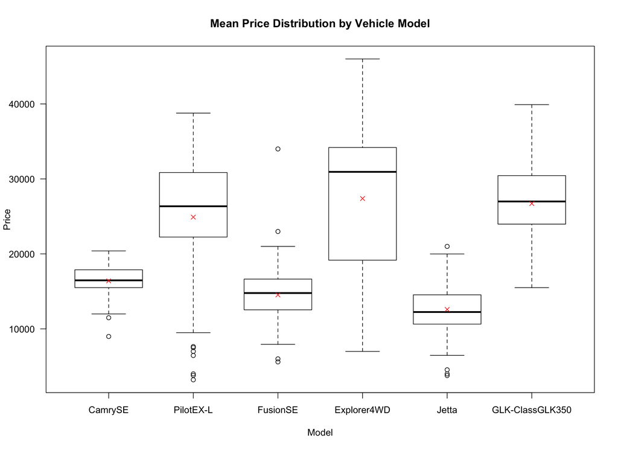

The above boxplots are ordered by country of manufacturer of the vehicle. All of the sedans have a lower mean price when compared to the SUVs. In addition, all of the SUVs have a much larger price distribution than the sedan made in the same country (EX. The Pilot EX-L (Japanese Manufacturer) has a higher price dist. than the CamrySE (Japanese Manufacturer)). Interestingly, the Honda Pilot EX-L has multiple outliers for Price due to all of the circles outside of the box-and-whisker plot compared to other cars.

*Question 2*

```r
#Produce summary statistics (mean and standard deviation) for each of the groups (car models) AND the entire sample of car prices

tapply(MyCars$Price,MyCars$Model,mean)
```

```
##         CamrySE       PilotEX-L        FusionSE     Explorer4WD
##        16397.75        24903.53        14526.08        27382.21
##           Jetta GLK-ClassGLK350
##        12592.65        26713.13
```

```r
tapply(MyCars$Price,MyCars$Model,sd)
```

```
##         CamrySE       PilotEX-L        FusionSE     Explorer4WD
##        1906.058        8435.239        3683.755        9415.806
##           Jetta GLK-ClassGLK350
##        3252.969        5588.743
```

```r
cat("\nOverall Mean: ",mean(MyCars$Price))
```

```
##
## Overall Mean:  20419.22
```

```r
cat("\nOverall Standard Dev.: ",sd(MyCars$Price))
```

```
##
## Overall Standard Dev.:  8541.399
```

*Question 3*

```r
#Based on just what you see in the boxplots and summary statistics comment on whether you think there are significant differences in the mean prices among your six car models. Also comment on any concerns you see about the conditions for the ANOVA for means model
```

The means for all of the sedans are much lower than the means for the SUVs. Similarly the Standard Deviations for all the sedans are lower than their SUV counterparts. ANOVA models want to determine if we predict “significantly” better using seperate means and SDs (alternative hypothesis) rather than the overall mean and SD (null hypothesis).

*Question 4*

Null Hypothesis: Overall mean price is the best predictor in our model

Alternative Hypothesis: Seperate mean prices for each model predict better than the overall mean.

```r
#Construct an ANOVA model for the mean price by car model. Include the output showing the ANOVA table; state hypotheses and provide a conclusion in the context of your data

Single_Car_Mod = aov(Price~factor(Model),data=MyCars)
summary(Single_Car_Mod)
```

```
##                Df    Sum Sq   Mean Sq F value Pr(>F)
## factor(Model)   5 2.204e+10 4.407e+09   120.8 <2e-16 ***
## Residuals     594 2.166e+10 3.647e+07
## ---
## Signif. codes:  0 '***' 0.001 '**' 0.01 '*' 0.05 '.' 0.1 ' ' 1
```

In the above model we see that the only predictor (factor(Model)) is significant with a p-value of effectively 0 (p < 2e-16). This mean that Model (a categorical predictor) is significant and we can reject the Null Hypothesis that the overall mean price of all the vehicles in the dataset is the best way to predict a new vehicle’s price.

*Question 5*

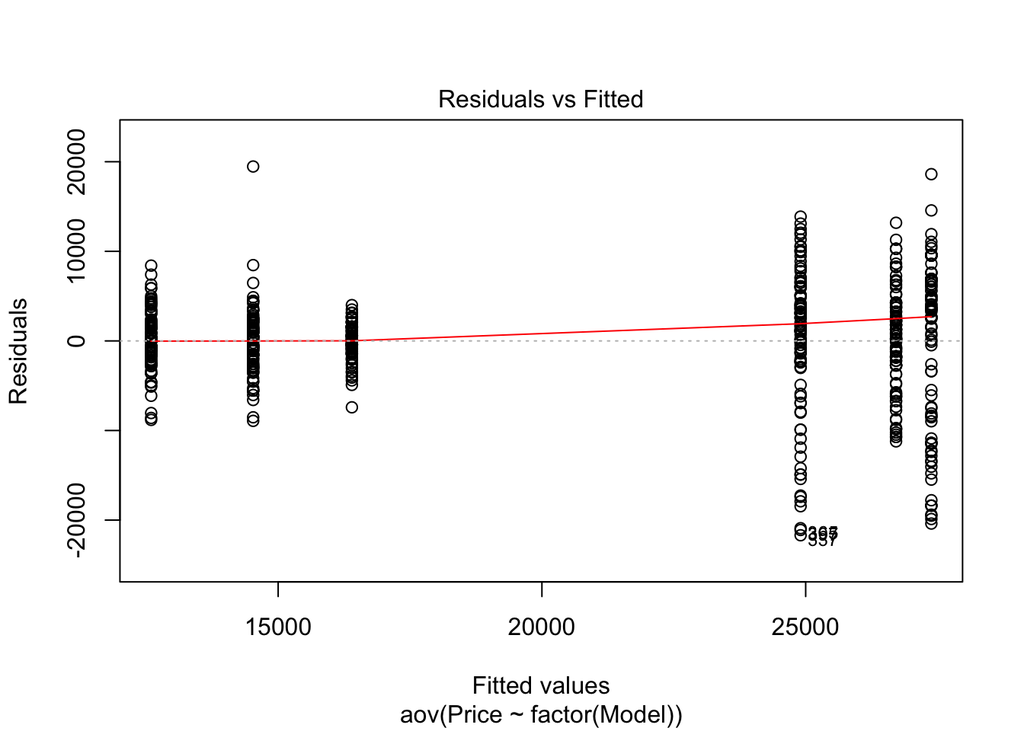

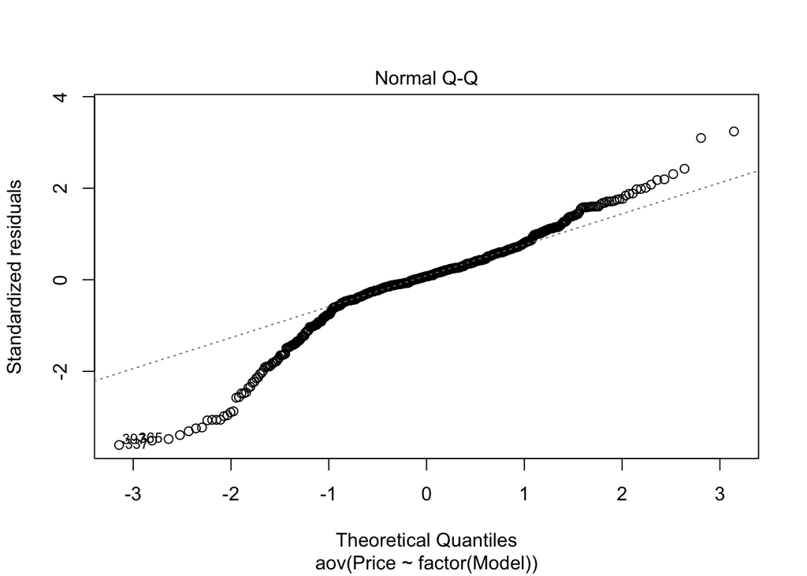

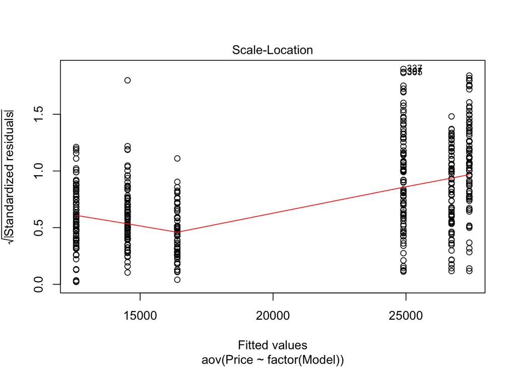

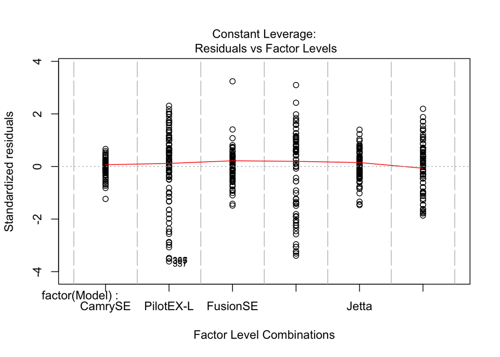

```r
#Produce plots and/or summary statistics and comment on the appropriateness of the following conditions for your data: normality of the residuals, and equality of the variances

plot(Single_Car_Mod)
```

*Question 6*

```r
#If your ANOVA model indicates there are significant differences among the car price means, discuss where the significant differences occur using Tukey HSD methods. If your ANOVA indicates there are not significant differences among the car price means, determine how different your means prices would need to be in order to find a significant difference using the Tukey HSD methods

#model indicates significant differences among the car price means.

TukeyHSD(Single_Car_Mod)
```

```
##   Tukey multiple comparisons of means
##     95% family-wise confidence level
##
## Fit: aov(formula = Price ~ factor(Model), data = MyCars)
##
## $`factor(Model)`
##                                  diff          lwr         upr     p adj
## PilotEX-L-CamrySE             8505.78   6063.96018  10947.5998 0.0000000
## FusionSE-CamrySE             -1871.67  -4313.48982    570.1498 0.2432063
## Explorer4WD-CamrySE          10984.46   8542.64018  13426.2798 0.0000000
## Jetta-CamrySE                -3805.10  -6246.91982  -1363.2802 0.0001453
## GLK-ClassGLK350-CamrySE      10315.38   7873.56018  12757.1998 0.0000000
## FusionSE-PilotEX-L          -10377.45 -12819.26982  -7935.6302 0.0000000
## Explorer4WD-PilotEX-L         2478.68     36.86018   4920.4998 0.0442832
## Jetta-PilotEX-L             -12310.88 -14752.69982  -9869.0602 0.0000000
## GLK-ClassGLK350-PilotEX-L     1809.60   -632.21982   4251.4198 0.2789031
## Explorer4WD-FusionSE         12856.13  10414.31018  15297.9498 0.0000000
## Jetta-FusionSE               -1933.43  -4375.24982    508.3898 0.2107196
## GLK-ClassGLK350-FusionSE     12187.05   9745.23018  14628.8698 0.0000000
## Jetta-Explorer4WD           -14789.56 -17231.37982 -12347.7402 0.0000000
## GLK-ClassGLK350-Explorer4WD   -669.08  -3110.89982   1772.7398 0.9702944
## GLK-ClassGLK350-Jetta        14120.48  11678.66018  16562.2998 0.0000000
```

Using TukeyHSD() we see that a lot of the pariwise comparisons of the vehicle’s price have a significant adjusted p-value (p < 0.05). The following comparisons of vehicle’s have a significant difference in their mean price:

PilotEX-L-CamrySE *

Explorer4WD-CamrySE *

Jetta-CamrySE

GLK-ClassGLK350-CamrySE *

FusionSE-PilotEX-L *

Explorer4WD-PilotEX-L

Jetta-PilotEX-L *

Explorer4WD-FusionSE *

GLK-ClassGLK350-FusionSE *

Jetta-Explorer4WD *

GLK-ClassGLK350-Jetta *

*Denotes the comparison is between a sedan and an SUV

Most of these comparisons are between a sedan and an SUV, which further supports the idea that there is a significant difference between the mean price of sedans and SUVs.

**Two-Way ANOVA**

*Question 7*

Null Hypothesis 1: The vehicle’s country of origin does not change the expected mean price of the vehicle

Alternative Hypothesis 2: The vehicle’s country of origin affects the expected mean price of the vehicle

Alternative Hypothesis 2: The vehicle type will change the expected mean price of the vehicle

```r
#Construct an ANOVA model for the mean price using the country of the company and the type of vehicle as predictors (without an interaction). Include the output showing the ANOVA table; state hypotheses and provide a conclusion in the context of your data. If your ANOVA model indicates there are significant differences among the car price means: Discuss where the significant differences occur using Tukey HSD methods

Multi_Car_Mod = aov(Price~factor(Country)+factor(VehicleType), data=MyCars)
summary(Multi_Car_Mod)
```

```
##                      Df    Sum Sq   Mean Sq F value Pr(>F)
## factor(Country)       2 1.854e+08 9.270e+07   2.452  0.087 .
## factor(VehicleType)   1 2.098e+10 2.098e+10 555.045 <2e-16 ***
## Residuals           596 2.253e+10 3.780e+07
## ---
## Signif. codes:  0 '***' 0.001 '**' 0.01 '*' 0.05 '.' 0.1 ' ' 1
```

Based on the model above, it appears that only VehicleType is a significant predictor in the model (p<2e-16). Based on this we cannot reject the first null hypothesis but we can reject the second null hypothesis. This means that we cannot conclude that the vehicle’s country of origin affects the price of a car but we can conclude that the vehicle type (car or SUV) does affect the price of the vehicle.

```r
TukeyHSD(Multi_Car_Mod)
```

```
##   Tukey multiple comparisons of means
##     95% family-wise confidence level
##
## Fit: aov(formula = Price ~ factor(Country) + factor(VehicleType), data = MyCars)
##
## $`factor(Country)`
##             diff        lwr      upr     p adj
## JPN-GER  997.750  -446.9024 2442.402 0.2368049
## USA-GER 1301.255  -143.3974 2745.907 0.0873826
## USA-JPN  303.505 -1141.1474 1748.157 0.8743821
##
## $`factor(VehicleType)`
##             diff      lwr      upr p adj
## SUV-Car 11827.46 10841.51 12813.42     0
```

Using TukeyHSD() we see that the only significant pairwise comparison is the one looking at VehicleType (SUV-Car). This further supports the model saying that only VehicleType is a significant predictor of a vehicle’s price.

*Question 8*

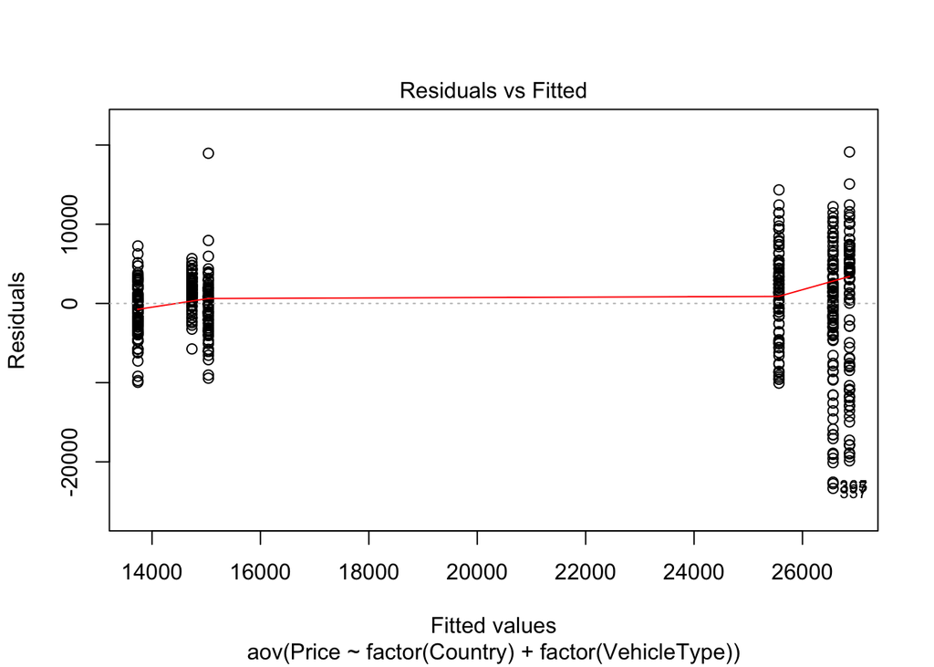

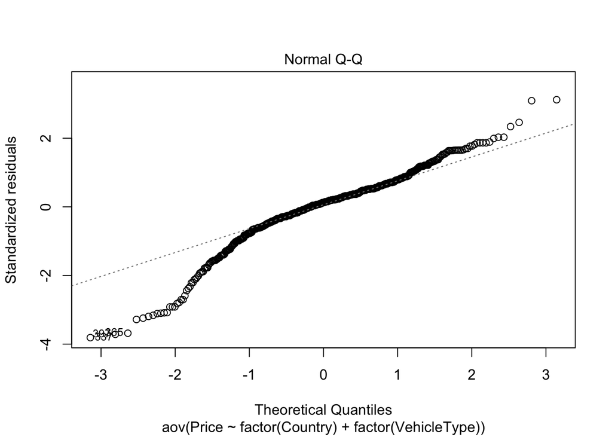

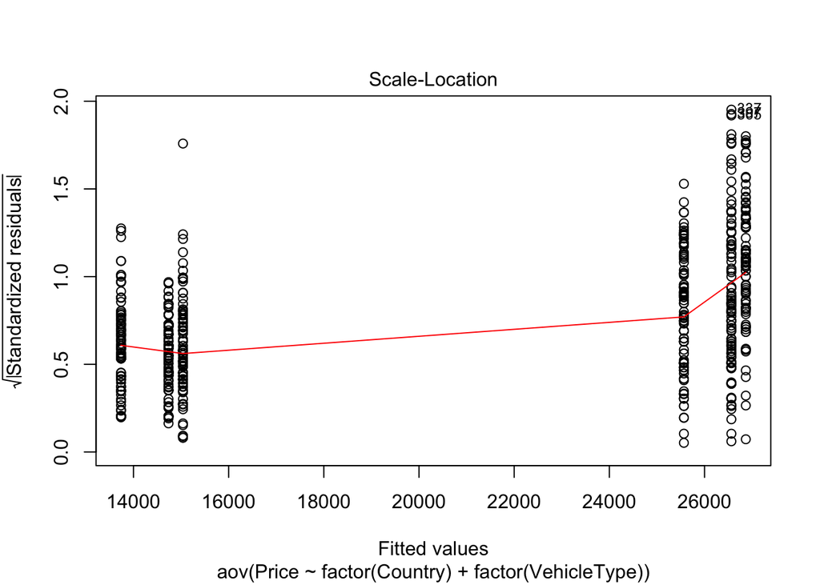

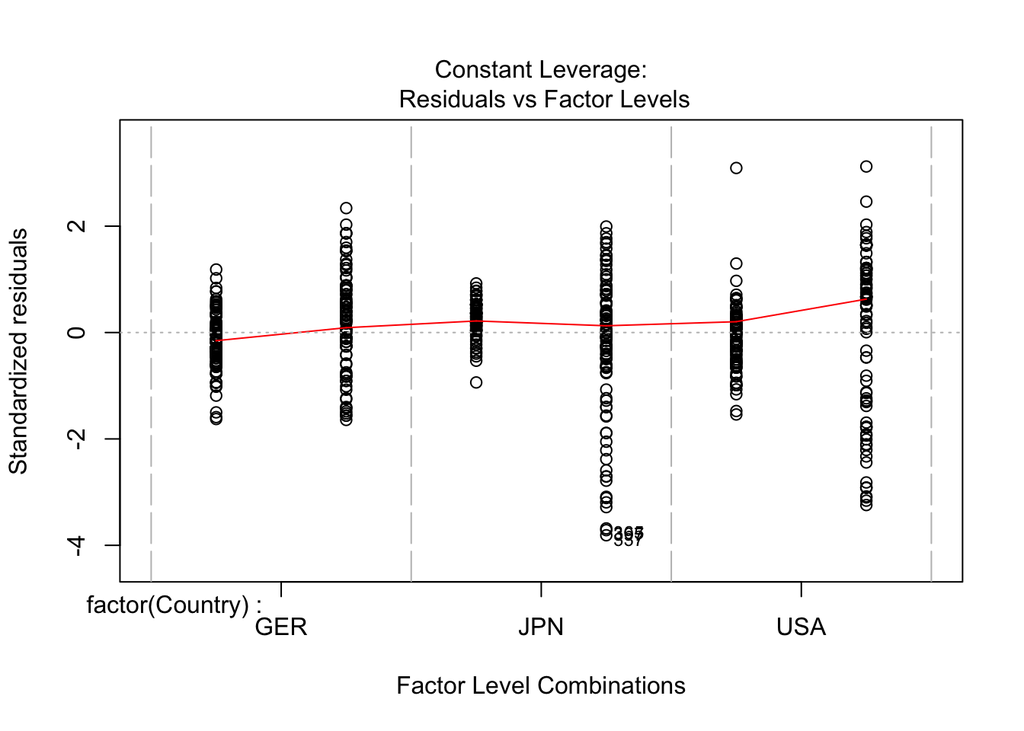

```r
#Produce plots and/or summary statistics to comment on the appropriateness of the following conditions for your data: normality of the residuals, and equality of the variances

plot(Multi_Car_Mod)
```

*Question 9*

Null Hypothesis 1: There is no difference in the mean price across the Country predictor

Alternative Hypothesis 1: At least one Country has a significantly different mean price

Null Hypothesis 2: There is no difference in the mean price across the VehicleType predictor

Alternative Hypothesis 2: At least one Vehicle Type has a significantly different mean price

Null Hypothesis 3: There is no difference in the mean price across the interaction of the Country and VehicleType predictors

Alternative Hypothesis 3: At least one of the interactions of Country and Vehicle Type has a significantly different mean price

```r
#Construct an ANOVA model for the mean price using the country of the company and the type of vehicle as predictors with the interaction. Include the output showing the ANOVA table; state hypotheses and provide a conclusion in the context of your data. If your ANOVA indicates there are significant differences among the car price means: Discuss where the significant differences occur using Tukey HSD methods

Interaction_Car_Mod = aov(Price~factor(Country)+factor(VehicleType)+factor(Country)*factor(VehicleType), data=MyCars)
summary(Interaction_Car_Mod)
```

```
##                                      Df    Sum Sq   Mean Sq F value
## factor(Country)                       2 1.854e+08 9.270e+07   2.542
## factor(VehicleType)                   1 2.098e+10 2.098e+10 575.333
## factor(Country):factor(VehicleType)   2 8.675e+08 4.337e+08  11.893
## Residuals                           594 2.166e+10 3.647e+07
##                                       Pr(>F)
## factor(Country)                       0.0796 .
## factor(VehicleType)                  < 2e-16 ***
## factor(Country):factor(VehicleType) 8.63e-06 ***
## Residuals
## ---
## Signif. codes:  0 '***' 0.001 '**' 0.01 '*' 0.05 '.' 0.1 ' ' 1
```

```r
TukeyHSD(Interaction_Car_Mod)
```

```
##   Tukey multiple comparisons of means
##     95% family-wise confidence level
##
## Fit: aov(formula = Price ~ factor(Country) + factor(VehicleType) + factor(Country) * factor(VehicleType), data = MyCars)
##
## $`factor(Country)`
##             diff        lwr      upr     p adj
## JPN-GER  997.750  -421.2141 2416.714 0.2247545
## USA-GER 1301.255  -117.7091 2720.219 0.0800282
## USA-JPN  303.505 -1115.4591 1722.469 0.8701056
##
## $`factor(VehicleType)`
##             diff      lwr      upr p adj
## SUV-Car 11827.46 10859.04 12795.89     0
##
## $`factor(Country):factor(VehicleType)`
##                     diff         lwr        upr     p adj
## JPN:Car-GER:Car  3805.10  1363.28018  6246.9198 0.0001453
## USA:Car-GER:Car  1933.43  -508.38982  4375.2498 0.2107196
## GER:SUV-GER:Car 14120.48 11678.66018 16562.2998 0.0000000
## JPN:SUV-GER:Car 12310.88  9869.06018 14752.6998 0.0000000
## USA:SUV-GER:Car 14789.56 12347.74018 17231.3798 0.0000000
## USA:Car-JPN:Car -1871.67 -4313.48982   570.1498 0.2432063
## GER:SUV-JPN:Car 10315.38  7873.56018 12757.1998 0.0000000
## JPN:SUV-JPN:Car  8505.78  6063.96018 10947.5998 0.0000000
## USA:SUV-JPN:Car 10984.46  8542.64018 13426.2798 0.0000000
## GER:SUV-USA:Car 12187.05  9745.23018 14628.8698 0.0000000
## JPN:SUV-USA:Car 10377.45  7935.63018 12819.2698 0.0000000
## USA:SUV-USA:Car 12856.13 10414.31018 15297.9498 0.0000000
## JPN:SUV-GER:SUV -1809.60 -4251.41982   632.2198 0.2789031
## USA:SUV-GER:SUV   669.08 -1772.73982  3110.8998 0.9702944
## USA:SUV-JPN:SUV  2478.68    36.86018  4920.4998 0.0442832
```

The ANOVA test tells us that both the VehicleType predictor and the interaction of the Country and VehicleType predictors were both significant with p-values of 2e-16(i.e. 0) and 8.63e-06 respectively. Looking at the TukeyHSD pariwise tests the following interactions were significant:

JPN:Car-GER:Car

GER:SUV-GER:Car

JPN:SUV-GER:Car

USA:SUV-GER:Car

GER:SUV-JPN:Car

JPN:SUV-JPN:Car

USA:SUV-JPN:Car

GER:SUV-USA:Car

JPN:SUV-USA:Car

USA:SUV-USA:Car

USA:SUV-JPN:SUV

As we can see from the above comparisons, most of the significant differences come from comparing SUVs to cars across the vehicle’s country of origin. This further indicates that the better predictor of a vehicle’s price is it’s Vehicle Type and not the Country the vehicle was made in.

*Question 10*

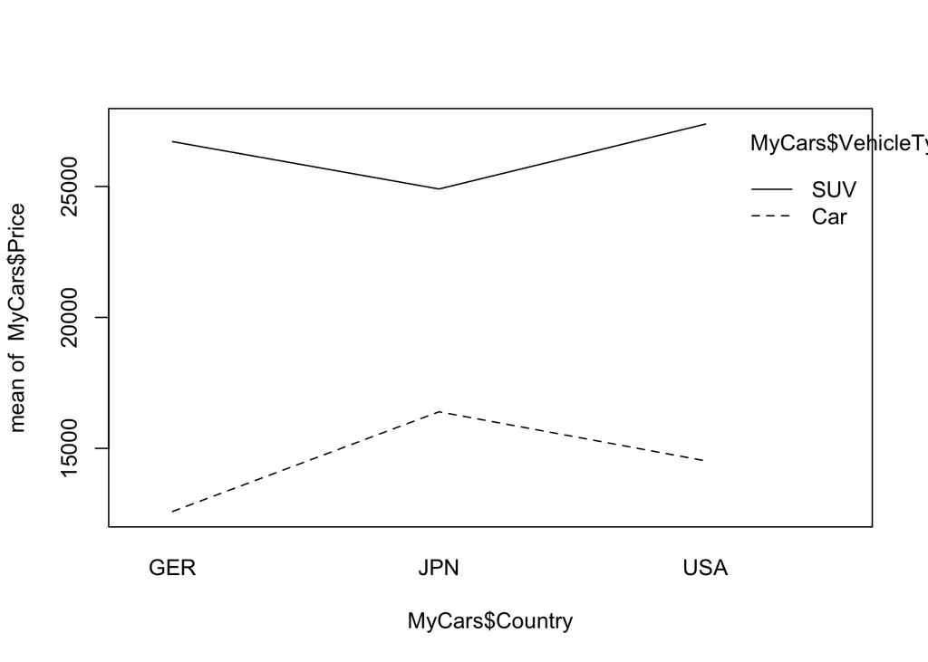

```r
#Produce two interaction plots for the previous model. If you found significant interactions in your hypothesis test, comment on how these interactions are shown in the plot

interaction.plot(MyCars$Country, MyCars$VehicleType,MyCars$Price)
```

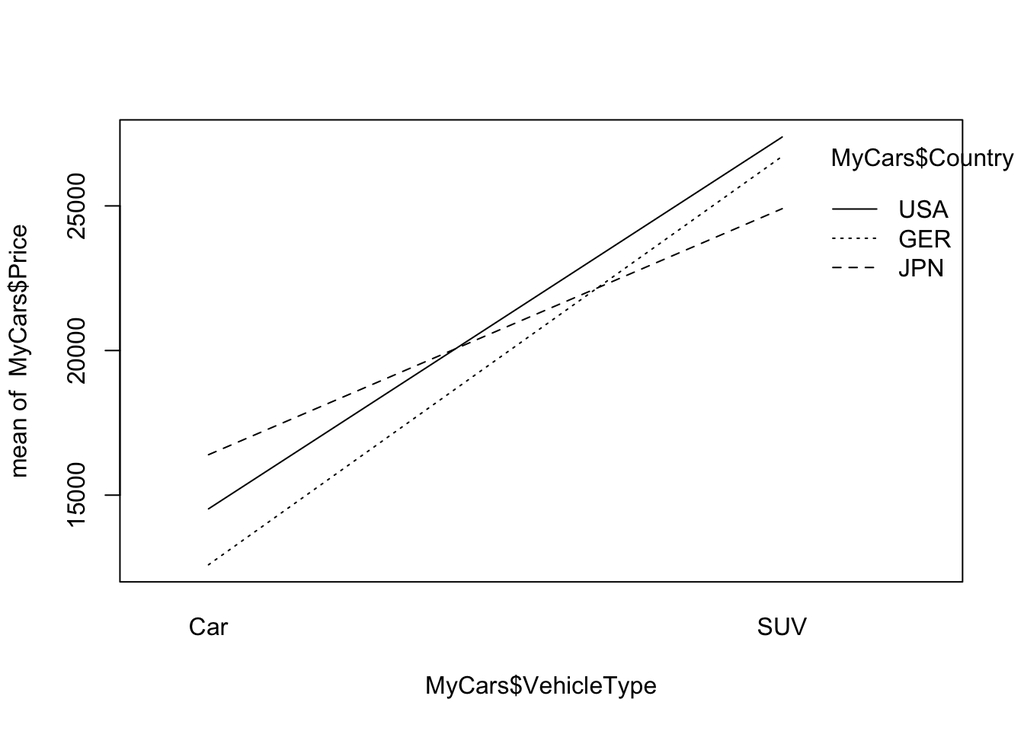

```r
interaction.plot(MyCars$VehicleType,MyCars$Country, MyCars$Price)
```

In the first interaction plot the thick line shows SUVs and the dashed line shows sedans. Across all countries of origin the SUV prices are a lot higher than the sedans. Japanese sedans and SUVs are the closest in price however the mean price difference for Japanese sedans and Japanese SUVs is $8,505.78 with American and German vehicles having a higher mean price difference. In the second interaction plot we can see that all the different countries show an increase in price as VehicleType changes from car to SUV.

**Additional Topics**

*Question 11*

```r
#Recall that we can also handle a categorical predictor with multiple categories (like your six car models) using ordinary multiple regression if we create indicator variables for each category and include all but one of the indicators in the model. Run an ordinary multiple regression to predict Price using the Model variable. Since Model has text values, R will automatically create the required indicator variables (i.e. treat it as a factor) and leave one out when fitting the model. Interpret each of the coefficients in the “dummy” regression by what they mean in the context of prices (or mean prices) of the different car models

Linear_Car_Mod = lm(Price~factor(Model), data=MyCars)
summary(Linear_Car_Mod)
```

```
##
## Call:
## lm(formula = Price ~ factor(Model), data = MyCars)
##
## Residuals:
##      Min       1Q   Median       3Q      Max
## -21693.5  -2214.4    462.9   3268.8  19468.9
##
## Coefficients:
##                              Estimate Std. Error t value Pr(>|t|)
## (Intercept)                   16397.8      603.9  27.152   <2e-16 ***
## factor(Model)PilotEX-L         8505.8      854.1   9.959   <2e-16 ***
## factor(Model)FusionSE         -1871.7      854.1  -2.191   0.0288 *
## factor(Model)Explorer4WD      10984.5      854.1  12.861   <2e-16 ***
## factor(Model)Jetta            -3805.1      854.1  -4.455    1e-05 ***
## factor(Model)GLK-ClassGLK350  10315.4      854.1  12.078   <2e-16 ***
## ---
## Signif. codes:  0 '***' 0.001 '**' 0.01 '*' 0.05 '.' 0.1 ' ' 1
##
## Residual standard error: 6039 on 594 degrees of freedom
## Multiple R-squared:  0.5043, Adjusted R-squared:  0.5001
## F-statistic: 120.8 on 5 and 594 DF,  p-value: < 2.2e-16
```

```r
anova(Linear_Car_Mod)
```

|  | Df | Sum Sq | Mean Sq | F value | Pr(>F) |
| --- | --- | --- | --- | --- | --- |
| factor(Model) | 5 | 22036208699 | 4407241740 | 120.8404 | 4.320499e-88 |
| Residuals | 594 | 21664132916 | 36471604 | NA | NA |

The dummy variables tell us that all of the categorical variables in factor(Model) are significant predictors of the vehicle’s price. This supports the idea that the seperate mean price values have a significant difference between the different vehicle models.

*Question 12*

```r
#One possible drawback of the analysis for this assignment is that different people might have chosen cars with quite different ages (or mileages) when collecting their samples. Thus an apparent “difference” between two car models might be due to one sample having considerably more older cars in it than another. Construct a model that allows you to check for price differences between your car models after accounting for variability that might be due to the mileage of the cars. Explain how you use the output from the model to address this question

#Use Mileage variable as a predictor

Multi_Linear_Car_Mod = lm(Price~factor(Model)+Mileage, data = MyCars)
summary(Multi_Linear_Car_Mod)
```

```
##
## Call:
## lm(formula = Price ~ factor(Model) + Mileage, data = MyCars)
##
## Residuals:
##    Min     1Q Median     3Q    Max
## -11811  -2069    -89   1767  14619
##
## Coefficients:
##                                Estimate Std. Error t value Pr(>|t|)
## (Intercept)                   2.197e+04  3.698e+02  59.422  < 2e-16 ***
## factor(Model)PilotEX-L        1.269e+04  4.895e+02  25.914  < 2e-16 ***
## factor(Model)FusionSE        -5.178e+02  4.773e+02  -1.085    0.278
## factor(Model)Explorer4WD      1.281e+04  4.785e+02  26.770  < 2e-16 ***
## factor(Model)Jetta           -2.658e+03  4.769e+02  -5.574 3.77e-08 ***
## factor(Model)GLK-ClassGLK350  1.100e+04  4.762e+02  23.107  < 2e-16 ***
## Mileage                      -1.555e-01  4.278e-03 -36.341  < 2e-16 ***
## ---
## Signif. codes:  0 '***' 0.001 '**' 0.01 '*' 0.05 '.' 0.1 ' ' 1
##
## Residual standard error: 3365 on 593 degrees of freedom
## Multiple R-squared:  0.8464, Adjusted R-squared:  0.8448
## F-statistic: 544.5 on 6 and 593 DF,  p-value: < 2.2e-16
```

```r
anova(Multi_Linear_Car_Mod)
```

|  | Df | Sum Sq | Mean Sq | F value | Pr(>F) |
| --- | --- | --- | --- | --- | --- |
| factor(Model) | 5 | 22036208699 | 4407241740 | 389.3089 | 1.303707e-184 |
| Mileage | 1 | 14950969580 | 14950969580 | 1320.6777 | 5.395834e-153 |
| Residuals | 593 | 6713163335 | 11320680 | NA | NA |

Based on the above ANOVA test, we can confirm that Mileage is a significant predictor when added to the full model comapred to a model without mileage as a predictor.

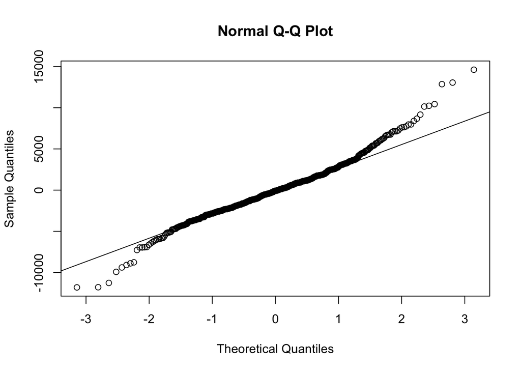

```r
#Check normality
qqnorm(Multi_Linear_Car_Mod$residuals)
qqline(Multi_Linear_Car_Mod$residuals)
```

The data doesn’t appear to fit a normal curve looking at the QQ plot.

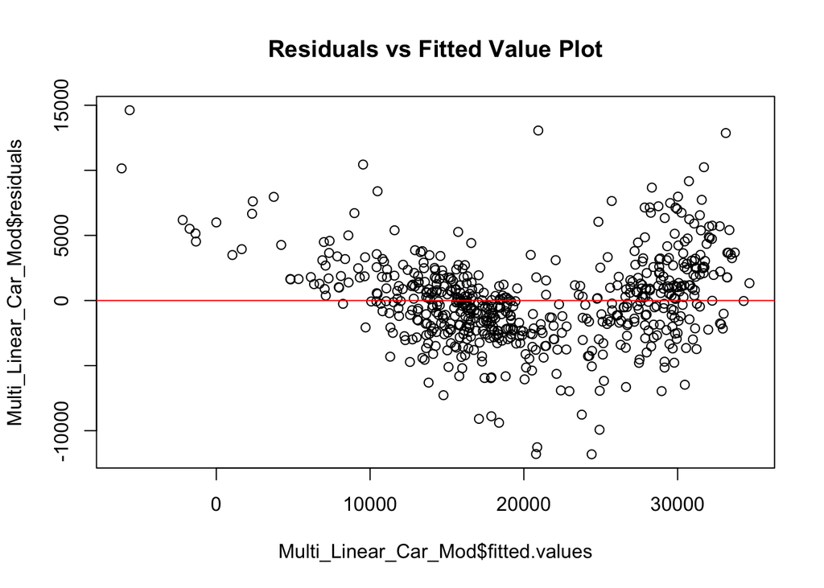

```r
plot(Multi_Linear_Car_Mod$residuals~Multi_Linear_Car_Mod$fitted.values, main="Residuals vs Fitted Value Plot")
abline(h=0, col="red")
```